# One-Week U.S. Equity Prediction Trading System Analysis

Thomas Benacci

2025-01-13

## 1. Introduction

This analysis evaluates a Random Forest-based trading system designed to predict holiday returns. The model selects stocks predicted to outperform the SPY benchmark, forming a concentrated long-only portfolio. We compare performance against both the equal-weighted stock universe and SPY.

## 2. Setup

```r
library(tidyverse)
library(lubridate)
library(zoo)
library(data.table)
library(scales)
```

## 3. Data

We merge the feature dataset with the Random Forest (trees = 2000, max depth = 7, splitting criterion = entropy) model predictions. The analysis covers 2009–2024, corresponding to the out-of-sample test period.

```r
# load feature dataset
feature_data <- fread("feature_data_holiday_20251112.csv", data.table = FALSE) %>%
  distinct(datadate, tic, .keep_all = TRUE) %>%
  mutate(model = "RF1")
# load RF model predictions
results_data <- fread("rf_holiday_results_01132026.csv", data.table = FALSE) %>%
  select(datadate, tic, prediction)
# merge and clean
data <- merge(results_data, feature_data, all.x = TRUE) %>%
  filter(datadate <= "2025-01-01") %>%
  rename(spy_return = spy_holiday_return, return = holiday_return)
rm(feature_data, results_data)

cat("Observations:", nrow(data), "\n")
```

```
## Observations: 406500
```

```r
cat("Date range:", as.character(min(data$datadate)), "to", as.character(max(data$datadate)), "\n")
```

```
## Date range: 2009-01-08 to 2024-12-26
```

```r
cat("Unique tickers:", length(unique(data$tic)), "\n")
```

```
## Unique tickers: 1013
```

```r
# load risk-free rate for potential Sharpe calculations
fedfunds <- fread("FEDFUNDS.csv", data.table = FALSE) %>%
  mutate(
    FEDFUNDS = FEDFUNDS / 100,
    rf_weekly = (1 + FEDFUNDS)^(1/52) - 1,
    rf_daily = (1 + FEDFUNDS)^(1/252) - 1
  )
```

## 4. Exploratory Data Analysis

### 4.1 Excess Return Distribution

Excess returns are calculated as stock return minus SPY return for each period. A distribution centered at zero indicates no systematic edge from random selection.

```r
excess_returns <- data$return - data$spy_return

# summary statistics
data.frame(
  Statistic = c("Mean", "Median", "Std Dev", "Min", "Max"),
  Value = round(c(
    mean(excess_returns, na.rm = TRUE),
    median(excess_returns, na.rm = TRUE),
    sd(excess_returns, na.rm = TRUE),
    min(excess_returns, na.rm = TRUE),
    max(excess_returns, na.rm = TRUE)
  ), 4)
)
```

```
##   Statistic   Value
## 1      Mean -0.0005
## 2    Median -0.0008
## 3   Std Dev  0.0373
## 4       Min -0.8742
## 5       Max  2.2742
```

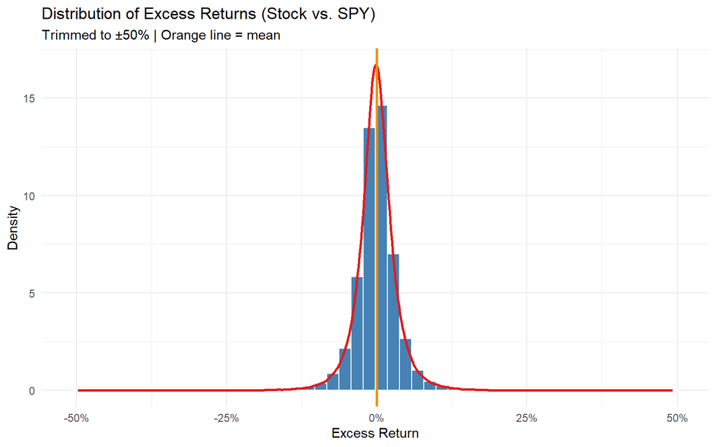

```r
excess_trimmed <- excess_returns[excess_returns > -0.5 & excess_returns < 0.5]

ggplot(data.frame(x = excess_trimmed), aes(x = x)) +
  geom_histogram(aes(y = after_stat(density)), bins = 50, fill = "steelblue", color = "white") +
  geom_density(color = "#E41A1C", linewidth = 1) +
  geom_vline(xintercept = 0, linetype = "dashed", color = "gray40") +
  geom_vline(xintercept = mean(excess_trimmed), color = "#F18F01", linewidth = 1) +
  labs(
    title = "Distribution of Excess Returns (Stock vs. SPY)",
    subtitle = "Trimmed to ±50% | Orange line = mean",
    x = "Excess Return", y = "Density"
  ) +
  theme_minimal() +
  scale_x_continuous(labels = percent_format())
```

The distribution centers near zero, consistent with weak-form market efficiency. Any edge must come from the prediction model, not the universe itself.

### 4.2 Target Variable Over Time

The target is binary: 1 if the stock beats SPY, 0 otherwise. A baseline of ~50% means random selection has no edge.

```r
cat("Overall target mean:", round(mean(data$target), 3), "\n")
```

```
## Overall target mean: 0.486
```

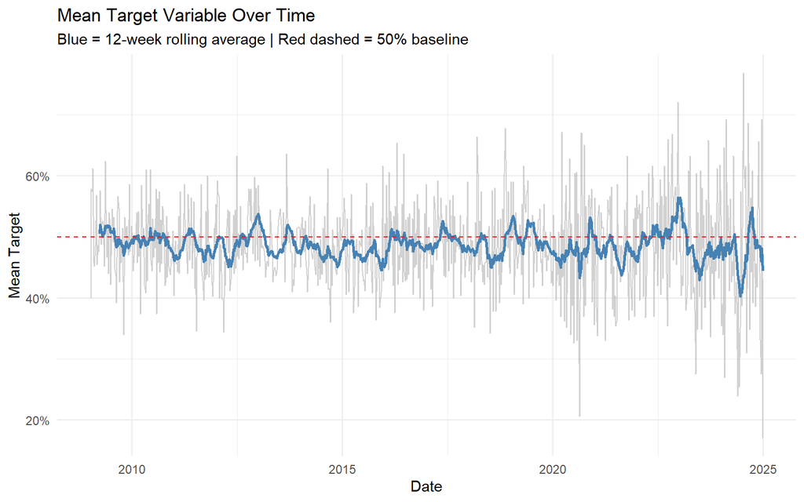

```r
df_target <- data %>%
  group_by(datadate) %>%
  summarize(mean_target = mean(target), .groups = "drop") %>%
  mutate(
    datadate = as.Date(datadate),
    rolling_mean = zoo::rollmean(mean_target, k = 12, fill = NA, align = "right")
  )

ggplot(df_target, aes(x = datadate)) +
  geom_line(aes(y = mean_target), color = "gray70", alpha = 0.6) +
  geom_line(aes(y = rolling_mean), color = "steelblue", linewidth = 1) +
  geom_hline(yintercept = 0.5, linetype = "dashed", color = "#E41A1C") +
  labs(
    title = "Mean Target Variable Over Time",
    subtitle = "Blue = 12-week rolling average | Red dashed = 50% baseline",
    x = "Date", y = "Mean Target"
  ) +
  theme_minimal() +
  scale_y_continuous(labels = percent_format())
```

Post-2020 shows higher dispersion, suggesting a regime change—possibly due to increased SPY concentration in mega-cap tech.

## 5. Feature Analysis

### 5.1 Feature Correlation Heatmap

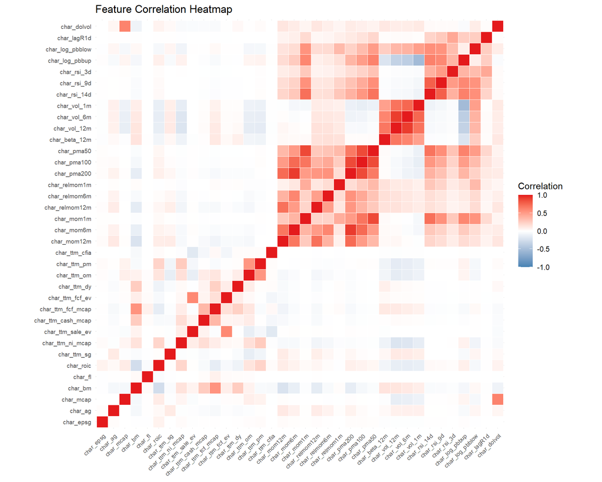

```r
feature_cor_mat <- data %>%
  select(starts_with("char_")) %>%
  cor(use = "pairwise.complete.obs")

cor_long <- as.data.frame(as.table(feature_cor_mat)) %>%
  rename(Feature1 = Var1, Feature2 = Var2, Correlation = Freq)

ggplot(cor_long, aes(x = Feature1, y = Feature2, fill = Correlation)) +
  geom_tile(color = "white", linewidth = 0.1) +
  scale_fill_gradient2(low = "steelblue", mid = "white", high = "#E41A1C", midpoint = 0, limits = c(-1, 1)) +
  labs(title = "Feature Correlation Heatmap", x = NULL, y = NULL) +
  theme_minimal() +
  theme(axis.text.x = element_text(angle = 45, hjust = 1, size = 7),
        axis.text.y = element_text(size = 7)) +
  coord_fixed()
```

Technical indicators show high inter-correlation; fundamentals are largely orthogonal. This suggests potential for dimensionality reduction.

### 5.2 Feature-Target Correlations

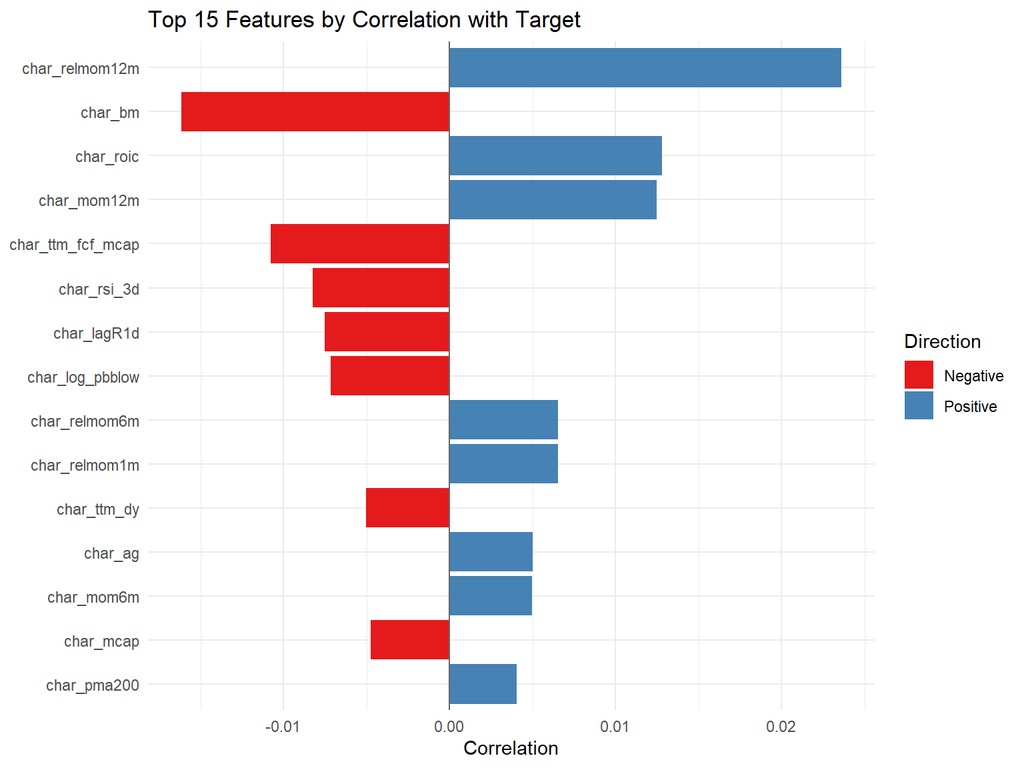

```r
target_cors <- sapply(data[grep("^char_", names(data))], function(x) cor(data$target, x, use = "complete.obs"))

cor_df <- data.frame(Feature = names(target_cors), Correlation = as.numeric(target_cors)) %>%
  arrange(desc(abs(Correlation))) %>%
  head(15) %>%
  mutate(Direction = ifelse(Correlation > 0, "Positive", "Negative"))

ggplot(cor_df, aes(x = reorder(Feature, abs(Correlation)), y = Correlation, fill = Direction)) +
  geom_col() +
  coord_flip() +
  scale_fill_manual(values = c("Positive" = "steelblue", "Negative" = "#E41A1C")) +
  geom_hline(yintercept = 0, color = "gray40") +
  labs(title = "Top 15 Features by Correlation with Target", x = NULL, y = "Correlation") +
  theme_minimal()
```

### 5.3 Feature Importance Summary Statistics

```r
# full correlation table sorted by absolute value
feature_cors <- sapply(data[grep("^char_", names(data))], function(x) cor(data$target, x, use = "complete.obs"))

importance_df <- data.frame(
  Feature = names(feature_cors),
  Correlation = as.numeric(feature_cors)
) %>%
  mutate(
    Abs_Corr = abs(Correlation),
    Direction = ifelse(Correlation > 0, "Positive", "Negative"),
    Rank = rank(-Abs_Corr)
  ) %>%
  arrange(Rank)

# summary of correlations
cat("=== Feature-Target Correlation Summary ===\n")
```

```
## === Feature-Target Correlation Summary ===
```

```r
cat("Total features:", nrow(importance_df), "\n")
```

```
## Total features: 36
```

```r
cat("Positive correlations:", sum(importance_df$Correlation > 0), "\n")
```

```
## Positive correlations: 17
```

```r
cat("Negative correlations:", sum(importance_df$Correlation < 0), "\n")
```

```
## Negative correlations: 19
```

```r
cat("Mean |correlation|:", round(mean(importance_df$Abs_Corr), 4), "\n")
```

```
## Mean |correlation|: 0.005
```

```r
cat("Max |correlation|:", round(max(importance_df$Abs_Corr), 4), "\n")
```

```
## Max |correlation|: 0.0236
```

```r
cat("Features with |corr| > 0.05:", sum(importance_df$Abs_Corr > 0.05), "\n")
```

```
## Features with |corr| > 0.05: 0
```

```r
cat("Features with |corr| > 0.02:", sum(importance_df$Abs_Corr > 0.02), "\n")
```

```
## Features with |corr| > 0.02: 1
```

```r
# full ranked table
importance_df %>%
  select(Rank, Feature, Correlation, Direction) %>%
  mutate(Correlation = round(Correlation, 4))
```

```
##    Rank            Feature Correlation Direction
## 1     1     char_relmom12m      0.0236  Positive
## 2     2            char_bm     -0.0162  Negative
## 3     3          char_roic      0.0128  Positive
## 4     4        char_mom12m      0.0125  Positive
## 5     5  char_ttm_fcf_mcap     -0.0108  Negative
## 6     6        char_rsi_3d     -0.0082  Negative
## 7     7        char_lagR1d     -0.0075  Negative
## 8     8    char_log_pbblow     -0.0072  Negative
## 9     9      char_relmom6m      0.0065  Positive
## 10   10      char_relmom1m      0.0065  Positive
## 11   11        char_ttm_dy     -0.0050  Negative
## 12   12            char_ag      0.0050  Positive
## 13   13         char_mom6m      0.0050  Positive
## 14   14          char_mcap     -0.0048  Negative
```

[output cut: 22 more lines]

### 5.4 Technical vs Fundamental Features

```r
# categorize features based on the data_prep naming conventions
# Technical: mom, relmom, pma, beta, vol, rsi, pbb, lagR, dolvol
# Fundamental: mcap, bm, fl, roic, epsg, ag, ttm_*
importance_df <- importance_df %>%
  mutate(
    Category = ifelse(
      grepl("mom|relmom|pma|beta|vol|rsi|pbb|lagR|dolvol", Feature, ignore.case = TRUE),
      "Technical",
      "Fundamental"
    )
  )

category_summary <- importance_df %>%
  group_by(Category) %>%
  summarise(
    N_Features = n(),
    Mean_Abs_Corr = round(mean(Abs_Corr), 4),
    Max_Abs_Corr = round(max(Abs_Corr), 4),
    Pct_Positive = round(mean(Correlation > 0) * 100, 1),
    .groups = "drop"
  ) %>%
  arrange(desc(Mean_Abs_Corr))

category_summary
```

```
## # A tibble: 2 × 5
##   Category    N_Features Mean_Abs_Corr Max_Abs_Corr Pct_Positive
##   <chr>            <int>         <dbl>        <dbl>        <dbl>
## 1 Technical           20        0.0052       0.0236         50
## 2 Fundamental         16        0.0047       0.0162         43.8
```

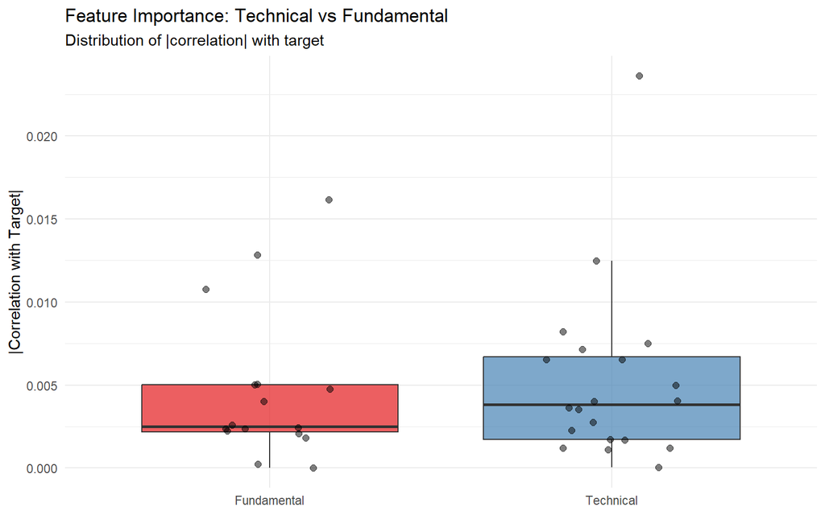

```r
ggplot(importance_df, aes(x = Category, y = Abs_Corr, fill = Category)) +
  geom_boxplot(alpha = 0.7, outlier.shape = NA) +
  geom_jitter(width = 0.2, alpha = 0.5, size = 2) +
  scale_fill_manual(values = c("Technical" = "steelblue", "Fundamental" = "#E41A1C")) +
  labs(
    title = "Feature Importance: Technical vs Fundamental",
    subtitle = "Distribution of |correlation| with target",
    x = NULL, y = "|Correlation with Target|"
  ) +
  theme_minimal() +
  theme(legend.position = "none")
```

```r
# top 5 features in each category
importance_df %>%
  group_by(Category) %>%
  slice_head(n = 5) %>%
  select(Category, Rank, Feature, Correlation) %>%
  mutate(Correlation = round(Correlation, 4)) %>%
  arrange(Rank)
```

```
## # A tibble: 10 × 4
## # Groups:   Category [2]
##    Category     Rank Feature           Correlation
##    <chr>       <dbl> <chr>                   <dbl>
##  1 Technical       1 char_relmom12m         0.0236
##  2 Fundamental     2 char_bm               -0.0162
##  3 Fundamental     3 char_roic              0.0128
##  4 Technical       4 char_mom12m            0.0125
##  5 Fundamental     5 char_ttm_fcf_mcap     -0.0108
##  6 Technical       6 char_rsi_3d           -0.0082
##  7 Technical       7 char_lagR1d           -0.0075
##  8 Technical       8 char_log_pbblow       -0.0072
##  9 Fundamental    11 char_ttm_dy           -0.005
## 10 Fundamental    12 char_ag                0.005
```

Technical indicators show higher average predictive power than fundamental factors, consistent with the short-term trading horizon.

## 6. Portfolio Construction

### 6.1 Parameters

```r
n_long <- 20 # number of long positions
prob_weighted <- TRUE # weight by prediction probability
periods_per_year <- 252 / 5 # weekly trading periods
# date-to-year mapping for labels
unique_dates <- unique(data$datadate)
year_labels <- seq(2009, 2025, length.out = length(unique_dates))
date_to_year <- setNames(year_labels, unique_dates)
```

### 6.2 RF Portfolio Formation

We select the top N stocks by predicted probability each period and form a probability-weighted portfolio.

```r
# select top N stocks by prediction
selected <- data %>%
  arrange(datadate, desc(prediction)) %>%
  group_by(datadate, model) %>%
  slice_head(n = n_long) %>%
  ungroup()
# calculate portfolio returns
portfolios <- selected %>%
  group_by(datadate, model) %>%
  summarise(
    return = if (prob_weighted) weighted.mean(return, prediction) else mean(return),
    .groups = "drop"
  ) %>%
  group_by(model) %>%
  arrange(datadate) %>%
  mutate(cumulative_return = cumprod(1 + return), datadate = as.Date(datadate)) %>%
  ungroup() %>%
  mutate(year = date_to_year[as.character(datadate)])
# add 1/N benchmark (equal-weighted universe)
equal_weighted <- data %>%
  group_by(datadate) %>%
  summarise(return = mean(return), .groups = "drop") %>%
  mutate(
    model = "1/N Universe",
    cumulative_return = cumprod(1 + return),
    year = date_to_year[as.character(datadate)],
    datadate = as.Date(datadate)
  )
# add SPY benchmark
spy_benchmark <- data %>%
  group_by(datadate) %>%
  summarise(return = mean(spy_return), .groups = "drop") %>%
  mutate(
    model = "SPY",
    cumulative_return = cumprod(1 + return),
    year = date_to_year[as.character(datadate)],
    datadate = as.Date(datadate)
  )
portfolios <- bind_rows(portfolios, equal_weighted, spy_benchmark)
```

### 6.3 Cumulative Performance

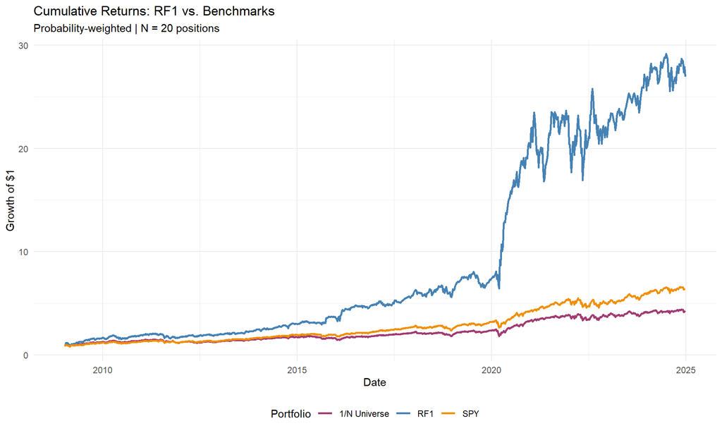

```r
ggplot(portfolios, aes(x = datadate, y = cumulative_return, color = model)) +
  geom_line(linewidth = 1) +
  scale_color_manual(values = c("RF1" = "steelblue", "1/N Universe" = "#A23B72", "SPY" = "#F18F01")) +
  scale_y_continuous(labels = comma) +
  labs(
    title = "Cumulative Returns: RF1 vs. Benchmarks",
    subtitle = paste0("Probability-weighted | N = ", n_long, " positions"),
    x = "Date", y = "Growth of $1", color = "Portfolio"
  ) +
  theme_minimal() +
  theme(legend.position = "bottom")
```

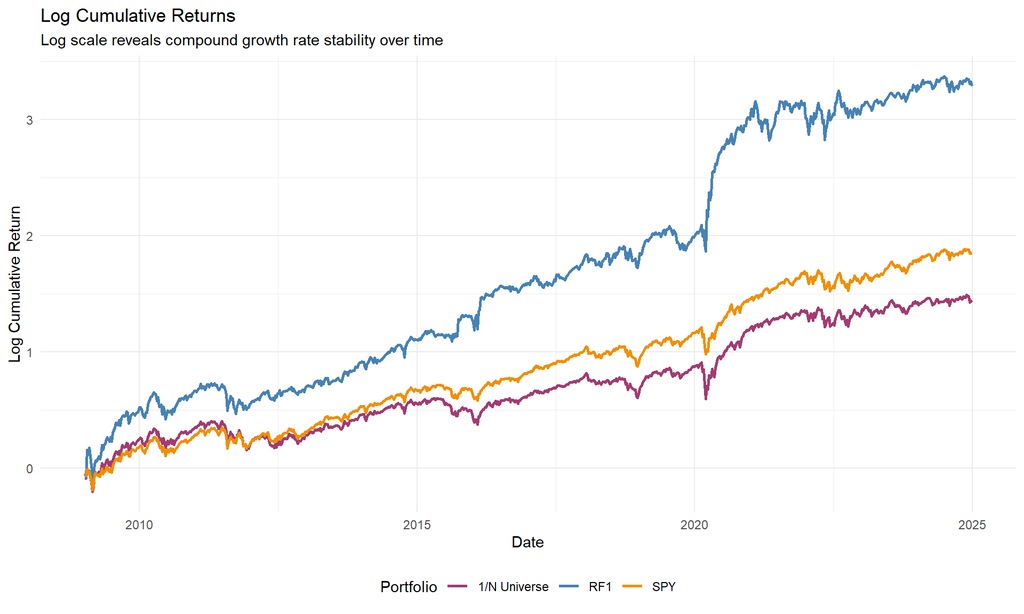

```r
ggplot(portfolios, aes(x = datadate, y = log(cumulative_return), color = model)) +
  geom_line(linewidth = 1) +
  scale_color_manual(values = c("RF1" = "steelblue", "1/N Universe" = "#A23B72", "SPY" = "#F18F01")) +
  labs(
    title = "Log Cumulative Returns",
    subtitle = "Log scale reveals compound growth rate stability over time",
    x = "Date", y = "Log Cumulative Return", color = "Portfolio"
  ) +
  theme_minimal() +
  theme(legend.position = "bottom")
```

The log plot is useful for identifying performance decay or regime changes in strategy alpha.

## 7. Performance Metrics

```r
spy_returns <- portfolios %>%
  filter(model == "SPY") %>%
  select(datadate, spy_return = return)

metrics <- portfolios %>%
  left_join(spy_returns, by = "datadate") %>%
  group_by(model) %>%
  summarise(
    Ann_Return = mean(return, na.rm = TRUE) * periods_per_year,
    Ann_Vol = sd(return, na.rm = TRUE) * sqrt(periods_per_year),
    Sharpe = Ann_Return / Ann_Vol,
    Max_DD = min((cumprod(1 + return) - cummax(cumprod(1 + return))) / cummax(cumprod(1 + return))),
    Info_Ratio = if (unique(model) == "SPY") NA_real_ else {
      active <- return - spy_return
      mean(active, na.rm = TRUE) * periods_per_year / (sd(active, na.rm = TRUE) * sqrt(periods_per_year))
    },
    .groups = "drop"
  ) %>%
  mutate(across(where(is.numeric), ~round(., 3)))

metrics
```

```
## # A tibble: 3 × 6
##   model        Ann_Return Ann_Vol Sharpe Max_DD Info_Ratio
##   <chr>             <dbl>   <dbl>  <dbl>  <dbl>      <dbl>
## 1 1/N Universe      0.103   0.17   0.606 -0.266     -0.496
## 2 RF1               0.241   0.277  0.87  -0.285      0.609
## 3 SPY               0.127   0.151  0.836 -0.203     NA
```

The RF system delivers higher returns than both benchmarks but with proportionally higher volatility. The Information Ratio quantifies risk-adjusted alpha relative to SPY—values between 0.5 and 1.0 are considered good.

## 8. Portfolio Size Sensitivity

We examine how performance changes with the number of positions held (N = 5, 10, 20, 50, 100, 250).

```r
sizes <- c(5, 10, 20, 50, 100, 250)

make_portfolio <- function(n) {
  data %>%
    arrange(datadate, desc(prediction)) %>%
    group_by(datadate) %>%
    slice_head(n = n) %>%
    summarise(return = if (prob_weighted) weighted.mean(return, prediction) else mean(return), .groups = "drop") %>%
    mutate(
      model = paste0("Top_", n),
      datadate = as.Date(datadate),
      cumulative_return = cumprod(1 + return)
    )
}

size_portfolios <- map_dfr(sizes, make_portfolio)
size_portfolios <- bind_rows(size_portfolios, equal_weighted, spy_benchmark)
```

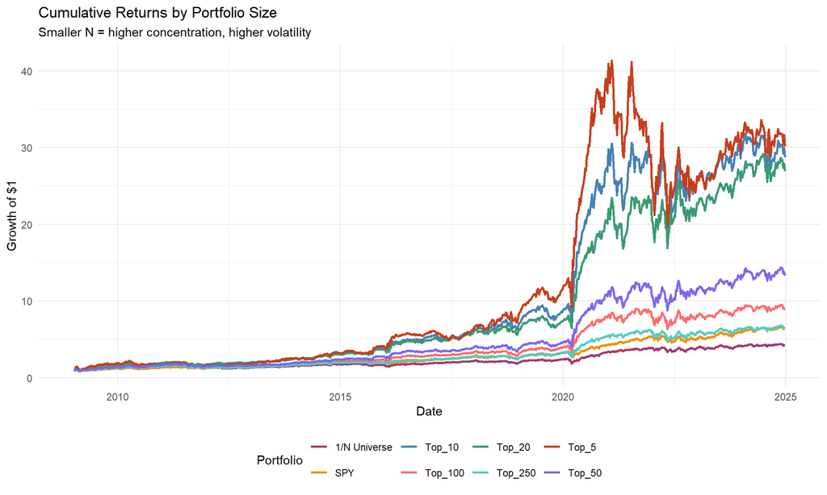

```r
size_colors <- c("Top_5" = "#C73E1D", "Top_10" = "steelblue", "Top_20" = "#3B9A74",
                 "Top_50" = "#7B68EE", "Top_100" = "#FF6B6B", "Top_250" = "#4ECDC4",
                 "1/N Universe" = "#A23B72", "SPY" = "#F18F01")

ggplot(size_portfolios, aes(x = datadate, y = cumulative_return, color = model)) +
  geom_line(linewidth = 1) +
  scale_color_manual(values = size_colors) +
  scale_y_continuous(labels = comma) +
  labs(
    title = "Cumulative Returns by Portfolio Size",
    subtitle = "Smaller N = higher concentration, higher volatility",
    x = "Date", y = "Growth of $1", color = "Portfolio"
  ) +
  theme_minimal() +
  theme(legend.position = "bottom")
```

```r
size_metrics <- size_portfolios %>%
  left_join(spy_returns, by = "datadate") %>%
  group_by(model) %>%
  summarise(
    Ann_Return = mean(return, na.rm = TRUE) * periods_per_year,
    Ann_Vol = sd(return, na.rm = TRUE) * sqrt(periods_per_year),
    Sharpe = Ann_Return / Ann_Vol,
    Max_DD = min((cumprod(1 + return) - cummax(cumprod(1 + return))) / cummax(cumprod(1 + return))),
    Info_Ratio = if (unique(model) == "SPY") NA_real_ else {
      active <- return - spy_return
      mean(active, na.rm = TRUE) * periods_per_year / (sd(active, na.rm = TRUE) * sqrt(periods_per_year))
    },
    .groups = "drop"
  ) %>%
  mutate(across(where(is.numeric), ~round(., 3)))

size_metrics
```

```
## # A tibble: 8 × 6
##   model        Ann_Return Ann_Vol Sharpe Max_DD Info_Ratio
##   <chr>             <dbl>   <dbl>  <dbl>  <dbl>      <dbl>
## 1 1/N Universe      0.103   0.17   0.606 -0.266     -0.496
## 2 SPY               0.127   0.151  0.836 -0.203     NA
## 3 Top_10            0.254   0.313  0.812 -0.368      0.553
## 4 Top_100           0.158   0.219  0.725 -0.294      0.272
## 5 Top_20            0.241   0.277  0.87  -0.285      0.609
## 6 Top_250           0.133   0.187  0.708 -0.231      0.084
## 7 Top_5             0.269   0.356  0.756 -0.52       0.502
## 8 Top_50            0.19    0.244  0.775 -0.294      0.42
```

All RF portfolio configurations show positive Information Ratios. Concentrated portfolios (smaller N) have higher return potential but also higher drawdown risk.

## 9. Conclusion

The RF trading system demonstrates positive alpha generation across multiple portfolio configurations. Key findings:

- The model delivers higher returns than both the 1/N universe and SPY benchmarks
- This comes at the cost of higher volatility and larger drawdowns
- Information Ratios remain positive across all position sizes tested
- Concentrated portfolios (N < 20) show the highest return potential but also the most tail risk

The drawdown of ~30% for the best long portfolio size (N = 20) by information ratio represents significant risk that must be considered when allocating capital. The post-2020 regime change (increased target dispersion) warrants monitoring for potential model degradation and research into new features as data became more accessible over time.